# Bayesian GLMM Part10

# 10 Model validation

**brms**

**pp check**

Post predictive checks provide additional diagnostics about the fit of the model. Specifically, they provide a comparison between predictions drawn from the model and the observed data used to train the model.

**See list of available diagnostics by name**

```r
available_ppc()
```

```
bayesplot PPC module:
  ppc_bars
  ppc_bars_grouped
  ppc_boxplot
  ppc_dens
  ppc_dens_overlay
  ppc_dens_overlay_grouped
  ppc_dots
  ppc_ecdf_overlay
  ppc_ecdf_overlay_grouped
  ppc_error_binned
  ppc_error_hist
  ppc_error_hist_grouped
  ppc_error_scatter
  ppc_error_scatter_avg
  ppc_error_scatter_avg_grouped
  ppc_error_scatter_avg_vs_x
  ppc_freqpoly
  ppc_freqpoly_grouped
  ppc_hist
  ppc_intervals
  ppc_intervals_grouped
  ppc_km_overlay
  ppc_km_overlay_grouped
  ppc_loo_intervals
  ppc_loo_pit_ecdf
  ppc_loo_pit_overlay
  ppc_loo_pit_qq
  ppc_loo_ribbon
  ppc_pit_ecdf
  ppc_pit_ecdf_grouped
  ppc_ribbon
  ppc_ribbon_grouped
  ppc_rootogram
  ppc_scatter
  ppc_scatter_avg
  ppc_scatter_avg_grouped
  ppc_stat
  ppc_stat_2d
  ppc_stat_freqpoly
  ppc_stat_freqpoly_grouped
  ppc_stat_grouped
  ppc_violin_grouped
```

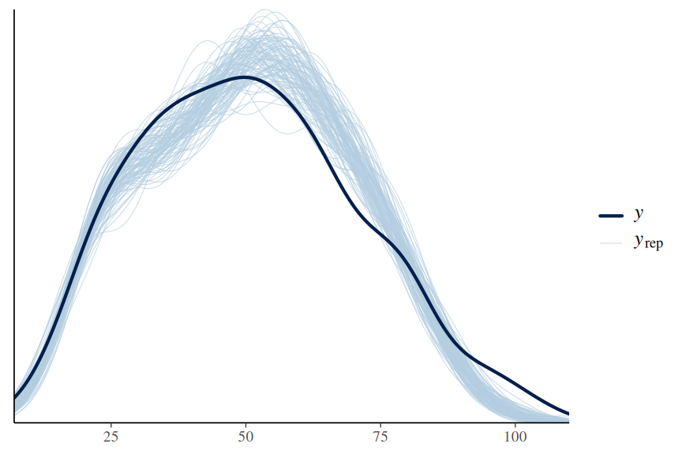

```r
ltmp_sub.brm3 |> pp_check(type = "dens_overlay", ndraws = 100)
```

The model draws appear to be consistent with the observed data.

- error_scatter_avg: this plots the observed values against the average residuals. Similar to a residual plot, we do not want to see any patterns in this plot. Note, this is not really that useful for models that involve a binomial response

```r
## ltmp_sub.brm3 %>% pp_check(type = 'error_scatter_avg')
```

This is not really interpretable

- intervals: plots the observed data overlayed on top of posterior predictions associated with each level of the predictor. Ideally, the observed data should all fall within the predictive intervals.

```
Using all posterior draws for ppc type 'intervals' by default.
```

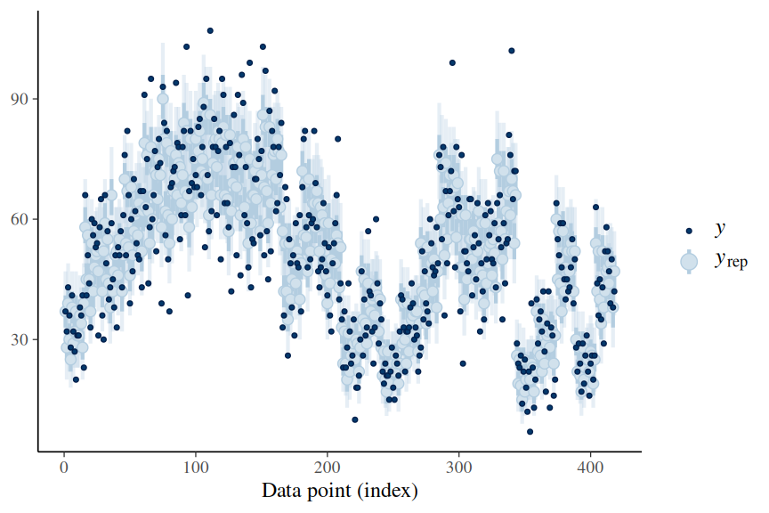

```r
ltmp_sub.brm3 %>% pp_check(group = "REEF", type = "intervals")
```

The `shinystan` package allows the full suite of MCMC diagnostics and posterior predictive checks to be accessed via a web interface.

```r
# library(shinystan)
# launch_shinystan(ltmp_sub.brm2)
```

**DHARMa residuals**

DHARMa residuals provide very useful diagnostics. Unfortunately, we cannot directly use the `simulateResiduals()` function to generate the simulated residuals. However, if we are willing to calculate some of the components yourself, we can still obtain the simulated residuals from the fitted stan model.

We need to supply:

- simulated (predicted) responses associated with each observation.
- observed values
- fitted (predicted) responses (averaged) associated with each observation

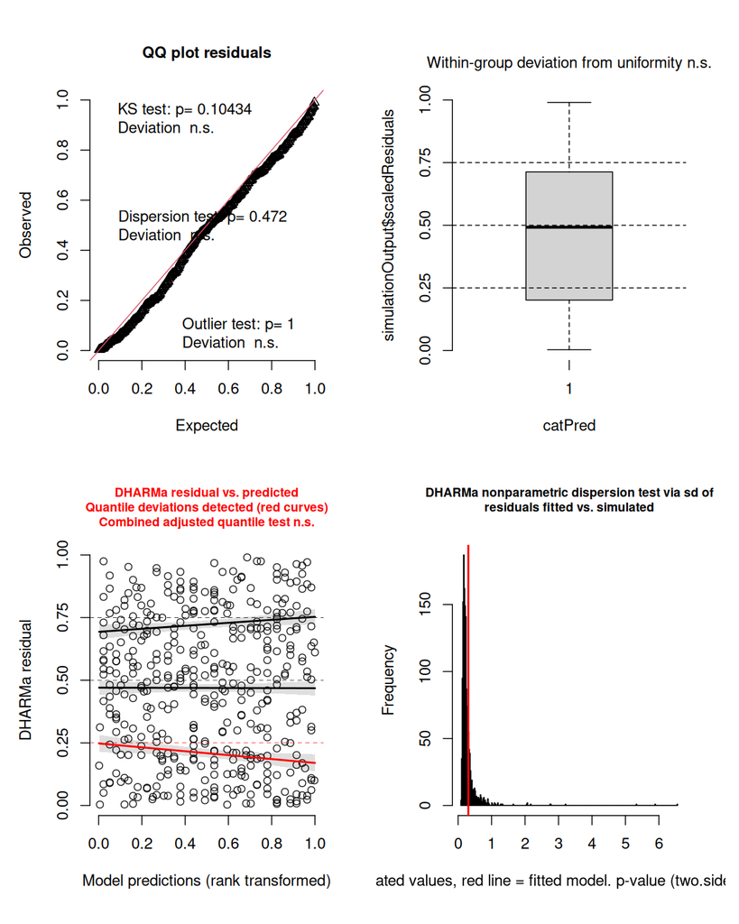

```r
ltmp_sub.resids <- make_brms_dharma_res(ltmp_sub.brm3, integerResponse = TRUE)
wrap_elements(~ testUniformity(ltmp_sub.resids)) +
  wrap_elements(~ plotResiduals(ltmp_sub.resids, form = factor(rep(1, nrow(ltmp_sub))))) +
  wrap_elements(~ plotResiduals(ltmp_sub.resids, quantreg = TRUE)) +
  wrap_elements(~ testDispersion(ltmp_sub.resids))
```

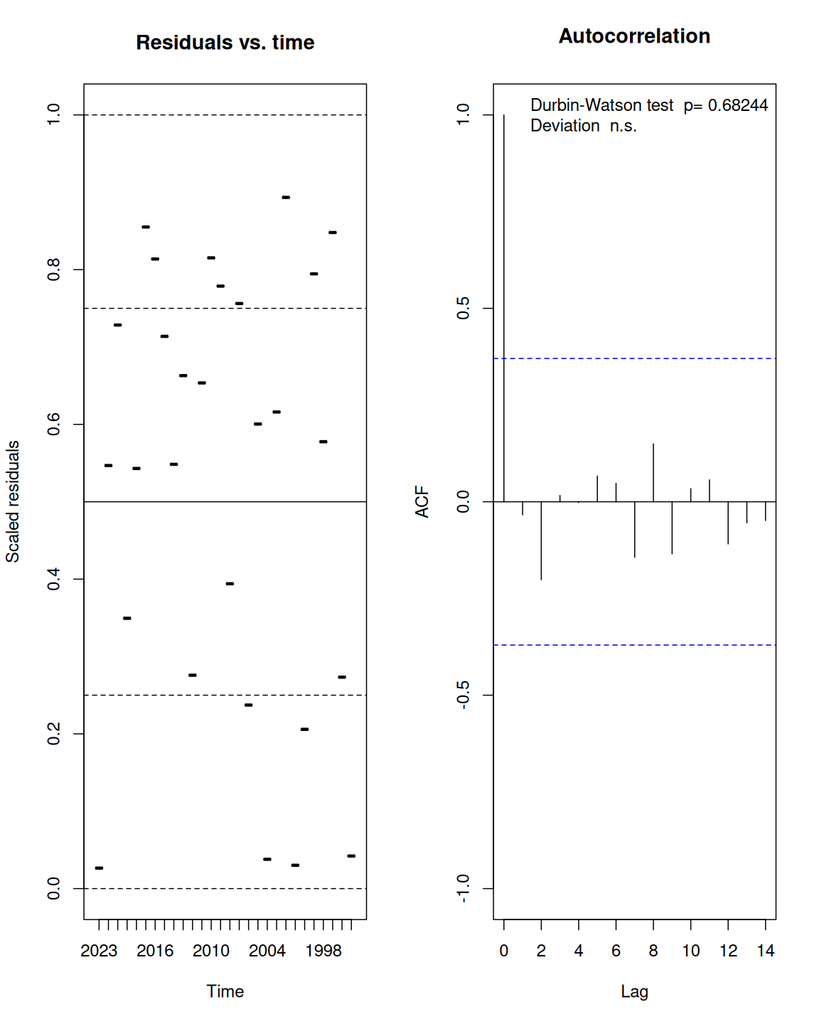

```
    Durbin-Watson test

data:  simulationOutput$scaledResiduals ~ 1
DW = 1.8473, p-value = 0.6824
alternative hypothesis: true autocorrelation is not 0
```

```r
resids2 <- recalculateResiduals(ltmp_sub.resids, group = unique(ltmp_sub$fREPORT_YEAR))
testTemporalAutocorrelation(resids2, time = unique(ltmp_sub$fREPORT_YEAR))
```

[output not shown]

[output cut: 447 more lines]

[output not shown]

```
Using  as id variables
```

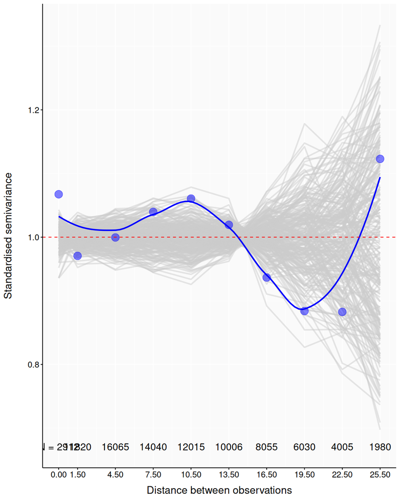

```r
library(geoR)
autocor_check(ltmp_sub, ltmp_sub.brm3, variable = "fREPORT_YEAR", n.sim = 250)
```

# 11 Model investigation

**brms**

**summary**

```r
ltmp_sub.brm3 %>% summary()
```

[output not shown]

**as_draws_df (posteriors)**

```r
ltmp_sub.brm3 |> as_draws_df()
```

```
# A draws_df: 500 iterations, 3 chains, and 55 variables
   b_Intercept b_fREPORT_YEAR2021 b_fREPORT_YEAR2020 b_fREPORT_YEAR2019
1        -0.71              -0.58              -0.60              -0.91
2        -0.70              -0.50              -0.51              -1.00
3        -0.58              -0.59              -0.56              -0.97
4        -0.82              -0.53              -0.48              -1.03
5        -0.81              -0.50              -0.43              -0.82
6        -0.65              -0.52              -0.48              -0.94
7        -0.70              -0.60              -0.53              -0.80
8        -0.76              -0.53              -0.53              -0.96
9        -0.78              -0.55              -0.46              -0.82
10       -0.67              -0.41              -0.45              -0.93
   b_fREPORT_YEAR2018 b_fREPORT_YEAR2017 b_fREPORT_YEAR2016 b_fREPORT_YEAR2015
1                -1.4               -1.3              -0.42              -0.75
2                -1.2               -1.2              -0.34              -0.74
3                -1.3               -1.4              -0.58              -0.78
4                -1.3               -1.4              -0.42              -0.69
5                -1.2               -1.3              -0.40              -0.71
6                -1.4               -1.3              -0.36              -0.70
7                -1.2               -1.4              -0.41              -0.72
8                -1.2               -1.3              -0.46              -0.61
9                -1.2               -1.2              -0.31              -0.65
10               -1.2               -1.3              -0.43              -0.61
# ... with 1490 more draws, and 47 more variables
# ... hidden reserved variables {'.chain', '.iteration', '.draw'}
```

```r
ltmp_sub.brm3 |>
  as_draws_df() |>
  dplyr::select(matches("^b_.*|^sd_.*")) |>
  mutate(across(matches("b_.*"), plogis)) |>
  summarise_draws(
    median,
    HDInterval::hdi,
    Pl = ~ mean(.x < 1),
    Pg = ~ mean(.x > 1),
    rhat,
    ess_bulk
  )
```

```
# A tibble: 30 × 8
   variable           median lower upper    Pl    Pg  rhat ess_bulk
   <chr>               <dbl> <dbl> <dbl> <dbl> <dbl> <dbl>    <dbl>
 1 b_Intercept         0.330 0.286 0.382     1     0 1.00     1136.
 2 b_fREPORT_YEAR2021  0.376 0.348 0.403     1     0 1.00     1416.
 3 b_fREPORT_YEAR2020  0.374 0.349 0.401     1     0 1.00     1325.
 4 b_fREPORT_YEAR2019  0.290 0.267 0.316     1     0 1.000    1327.
 5 b_fREPORT_YEAR2018  0.220 0.198 0.243     1     0 1.000    1326.
 6 b_fREPORT_YEAR2017  0.211 0.189 0.234     1     0 0.999    1512.
 7 b_fREPORT_YEAR2016  0.406 0.381 0.434     1     0 1.00     1229.
 8 b_fREPORT_YEAR2015  0.331 0.305 0.357     1     0 1.00     1350.
 9 b_fREPORT_YEAR2014  0.267 0.241 0.292     1     0 1.00     1195.
10 b_fREPORT_YEAR2013  0.244 0.222 0.268     1     0 0.999    1263.
# ℹ 20 more rows
```

**\(R^2\)**

```r
ltmp_sub.brm3 |>
  bayes_R2(re.form = NA, summary = FALSE) |>
  median_hdci()
```

```
          y      ymin      ymax .width .point .interval
1 0.6750637 0.6364879 0.7171351   0.95 median      hdci
```

```r
ltmp_sub.brm3 |>
  bayes_R2(re.form = ~ (1 | REEF_SITE), summary = FALSE) |>
  median_hdci()
```

```
          y      ymin      ymax .width .point .interval
1 0.6696107 0.6418767 0.6946751   0.95 median      hdci
```

```r
ltmp_sub.brm3 |>
  bayes_R2(re.form = ~ (1 | REEF_SITE) + (1 | REEF_SITE_TRANSECT), summary = FALSE) |>
  median_hdci()
```

```
          y      ymin      ymax .width .point .interval
1 0.7688076 0.7560056 0.7790249   0.95 median      hdci
```

# 12 Further investigations

**brms**

**Cellmeans**

Lets start by calculating the cell means

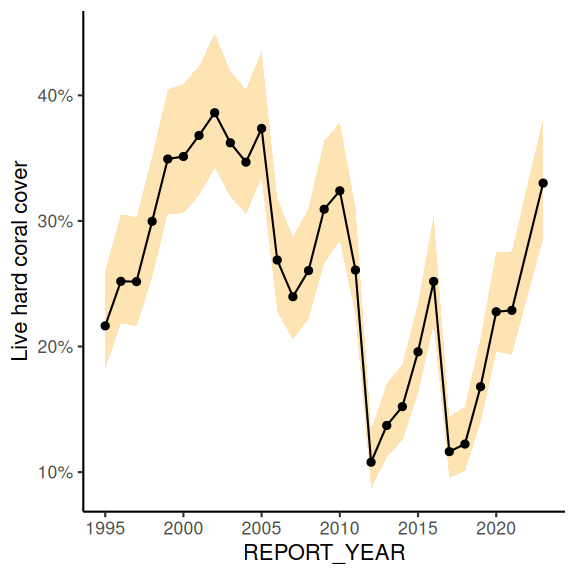

```r
ltmp_sub.brm3 |>
  emmeans(~fREPORT_YEAR, type = "response") |>
  as.data.frame() |>
  mutate(
    fREPORT_YEAR = factor(fREPORT_YEAR, levels = rev(levels(fREPORT_YEAR))),
    REPORT_YEAR = as.numeric(as.character(fREPORT_YEAR))
  ) |>
  ggplot(aes(y = prob, x = REPORT_YEAR)) +
  geom_ribbon(aes(ymin = lower.HPD, ymax = upper.HPD), fill = "orange", alpha = 0.3) +
  geom_line() +
  geom_point() +
  theme_classic() +
  scale_y_continuous("Live hard coral cover", label = scales::percent_format())
```

**Effects**

```r
newdata <- list(fREPORT_YEAR = c(2011, 2012))
ltmp_sub.brm3 |>
  emmeans(~fREPORT_YEAR,
    at = newdata,
    type = "response"
  )
```

```
 fREPORT_YEAR  prob lower.HPD upper.HPD
         2011 0.261    0.2252     0.311
         2012 0.108    0.0866     0.134

Point estimate displayed: median
Results are back-transformed from the logit scale
HPD interval probability: 0.95
```

```r
ltmp_sub.brm3 |>
  emmeans(~fREPORT_YEAR,
    at = newdata,
    type = "response"
  ) |>
  pairs(reverse = TRUE)
```

```
 contrast                            odds.ratio lower.HPD upper.HPD
 fREPORT_YEAR2012 / fREPORT_YEAR2011      0.343     0.296     0.389

Point estimate displayed: median
Results are back-transformed from the log odds ratio scale
HPD interval probability: 0.95
```

```r
newdata <- list(fREPORT_YEAR = c(2000:2005, 2012:2013))
cmat <- cbind(c(rep(1 / 6, 6), rep(-1 / 2, 2)))
ltmp_sub.brm3 |>
  emmeans(~fREPORT_YEAR,
    at = newdata,
    type = "response"
  ) |>
  regrid() |>
  contrast(method = list(fREPORT_YEAR = cmat))
```

```
 contrast     estimate lower.HPD upper.HPD
 fREPORT_YEAR    0.242     0.219     0.272

Point estimate displayed: median
HPD interval probability: 0.95
```

```r
ltmp_sub.brm3 |>
  emmeans(~fREPORT_YEAR,
    at = list(fREPORT_YEAR = c(2011, 2012)),
    type = "link"
  ) |>
  pairs(reverse = TRUE) |>
  tidy_draws() |>
  exp() |>
  summarise_draws(
    median,
    HDInterval::hdi,
    Pl = ~ mean(.x < 1),
    Pg = ~ mean(.x > 1)
  )
```

```
# A tibble: 1 × 6
  variable                                     median lower upper    Pl    Pg
  <chr>                                         <dbl> <dbl> <dbl> <dbl> <dbl>
1 contrast fREPORT_YEAR2012 - fREPORT_YEAR2011  0.343 0.296 0.389     1     0
```

```r
cmat <- cbind(c(rep(-1 / 7, 7), 1))
ltmp_sub.brm3 |>
  emmeans(~fREPORT_YEAR,
    at = list(fREPORT_YEAR = c(1999:2005, 2012)),
    type = "response"
  ) |>
  contrast(method = list(fREPORT_YEAR = cmat))
```

```
 contrast     odds.ratio lower.HPD upper.HPD
 fREPORT_YEAR      0.213     0.188     0.238

Point estimate displayed: median
Results are back-transformed from the log odds ratio scale
HPD interval probability: 0.95
```

```r
ltmp_sub.brm3 |>
  emmeans(~fREPORT_YEAR,
    at = list(fREPORT_YEAR = c(1999:2005, 2012)),
    type = "response"
  ) |>
  regrid() |>
  contrast(method = list(fREPORT_YEAR = cmat))
```

```
 contrast     estimate lower.HPD upper.HPD
 fREPORT_YEAR   -0.255    -0.286    -0.229

Point estimate displayed: median
HPD interval probability: 0.95
```

```r
ltmp.form <- bf(
  n.points | trials(total.points) ~ s(REPORT_YEAR) +
    (1 | REEF_SITE) + (1 | REEF_SITE_TRANSECT),
  family = binomial(link = "log")
)
get_prior(ltmp.form, data = ltmp_sub)
```

```
                  prior     class           coef              group resp dpar
                 (flat)         b
                 (flat)         b sREPORT_YEAR_1
 student_t(3, 3.9, 2.5) Intercept
   student_t(3, 0, 2.5)        sd
   student_t(3, 0, 2.5)        sd                         REEF_SITE
   student_t(3, 0, 2.5)        sd      Intercept          REEF_SITE
   student_t(3, 0, 2.5)        sd                REEF_SITE_TRANSECT
   student_t(3, 0, 2.5)        sd      Intercept REEF_SITE_TRANSECT
   student_t(3, 0, 2.5)       sds
   student_t(3, 0, 2.5)       sds s(REPORT_YEAR)
 nlpar lb ub       source
                  default
             (vectorized)
                  default
        0         default
        0    (vectorized)
        0    (vectorized)
        0    (vectorized)
        0    (vectorized)
        0         default
        0    (vectorized)
```

```r
ltmp_sub |>
  summarise(
    Median = median(qlogis(HC / 100)),
    MAD = mad(qlogis(HC / 100)),
    N = mean(total.points)
  )
```

```
# A tibble: 1 × 3
  Median   MAD     N
   <dbl> <dbl> <dbl>
1  -1.10 0.579  198.
```

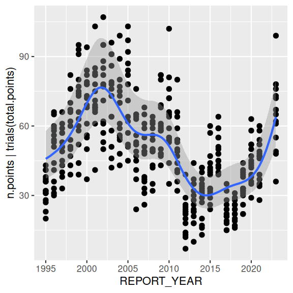

```r
priors <- prior(normal(-1.1, 0.8), class = "Intercept") +
  prior(normal(0, 1), class = "b") +
  prior(student_t(3, 0, 1), class = "sd") +
  prior(student_t(3, 0, 10), class = "sds")
ltmp_sub.brm4 <- brm(ltmp.form,
  data = ltmp_sub,
  prior = priors,
  sample_prior = "yes",
  iter = 5000,
  warmup = 2000,
  chains = 3, cores = 3,
  thin = 10,
  refresh = 100,
  control = list(adapt_delta = 0.99, max_treedepth = 20),
  backend = "rstan"
)
##
ltmp_sub.brm4 |>
  conditional_effects(conditions = data.frame(total.points = 200)) |>
  plot(points = TRUE)
```

```r
data.frame(mgcv::smoothCon(s(REPORT_YEAR), data = ltmp_sub)[[1]]$X) |>
  head()
```

[output not shown]

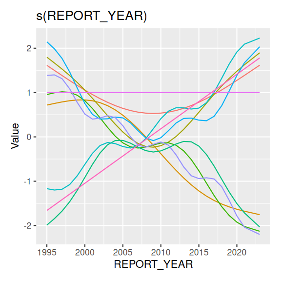

```r
## data.frame(mgcv::smoothCon(s(REPORT_YEAR, k=3),  data=ltmp_sub)[[1]]$REPORT_YEAR) |>
##   bind_cols(ltmp_sub)

gratia::basis(s(REPORT_YEAR), data = ltmp_sub) |> gratia::draw()
```

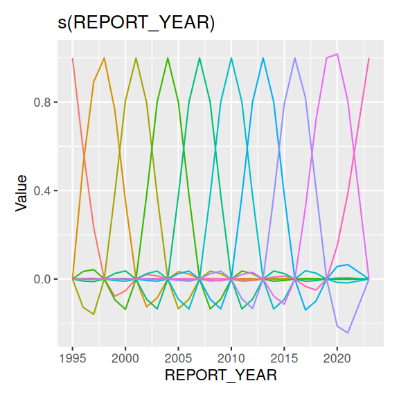

```r
gratia::basis(s(REPORT_YEAR, bs = "cr"), data = ltmp_sub) |> gratia::draw()
```

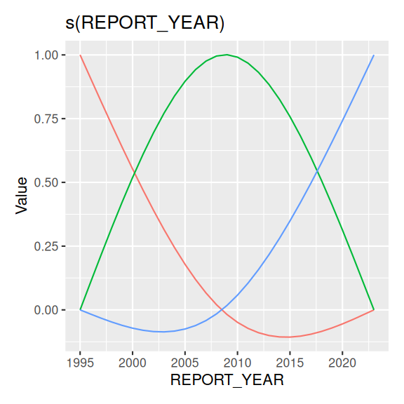

```r
gratia::basis(s(REPORT_YEAR, bs = "cr", k = 3), data = ltmp_sub) |> gratia::draw()
```

```
Setting all 'trials' variables to 1 by default if not specified otherwise.
```

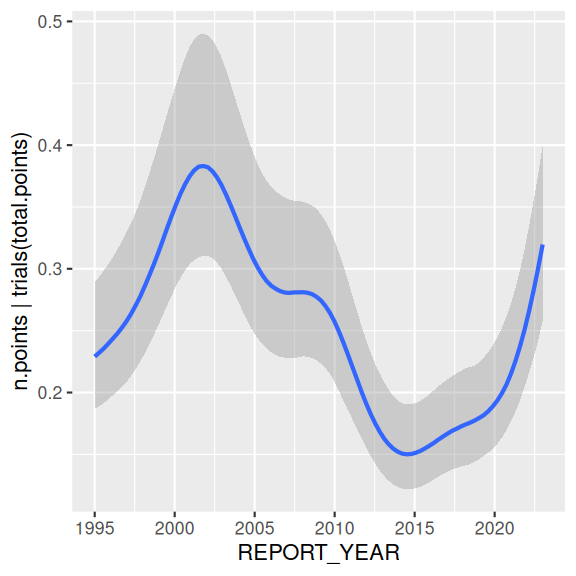

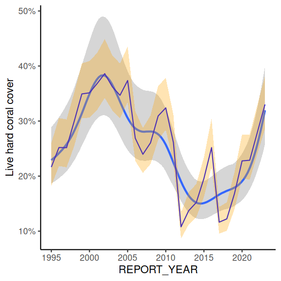

```r
ltmp_glmm <- ltmp_sub.brm3 |>
  emmeans(~fREPORT_YEAR, type = "response") |>
  as.data.frame() |>
  mutate(
    fREPORT_YEAR = factor(fREPORT_YEAR, levels = rev(levels(fREPORT_YEAR))),
    REPORT_YEAR = as.numeric(as.character(fREPORT_YEAR))
  )
ltmp_sub.brm4 |>
  conditional_effects() |>
  plot() |>
  _[[1]] +
  geom_line(
    data = ltmp_glmm, inherit.aes = FALSE,
    aes(y = prob, x = REPORT_YEAR), colour = "blue"
  ) +
  geom_ribbon(
    data = ltmp_glmm, inherit.aes = FALSE,
    aes(
      y = prob, x = REPORT_YEAR,
      min = lower.HPD, ymax = upper.HPD
    ), fill = "orange", alpha = 0.3
  ) +
  theme_classic() +
  scale_y_continuous("Live hard coral cover", label = scales::percent_format())
```